# Trabajo Práctico I AID-2022

# Ejercicio 1

Seis candidatas son evaluadas para el puesto de recepcionista en una empresa, para ello pasan por dos entrevistas. En la primera las evalúa el responsable de recursos humanos de la empresa (juez 1) y en la segunda el responsable del área de la cual van a depender (juez 2). La asignación de puntajes es en cordialidad, presencia y manejo de idiomas. Los puntajes asignados independientemente por estos jueces se encuentran en el archivo recepcionistas.xls.

```r
#Cargamos las librerías
library(readxl)#lectura
library(dplyr) #manipulacion de datos
library(kableExtra) #tablas
library(ggplot2) #graficos
library(tidyverse) #manipulacion de datos
library(ggpubr) #para juntar
library(ggforce) # grafico de violin y jitter
library(GGally) # ggpairs
library(corrplot) # para correlogramas
```

- 1. Calcule en promedio por juez de cada una de las aspirantes. ¿Cuál le parece que seleccionaría cada uno de ellos? ¿Existe coincidencia?

```r
#leemos los datos
recepcionistas <- read_excel("C:/Users/Debora/Dropbox/AustralPosgrado/DataScience/Datos/recepcionistas.xls")
recepcionistas
```

```
## # A tibble: 6 × 7
##   candidatos cord.juez1 pres.juez1 idiom.juez1 cord.juez2 pres.juez2 idiom.juez2
##   <chr>           <dbl>      <dbl>       <dbl>      <dbl>      <dbl>       <dbl>
## 1 Mariana            80         90          70         60         78          80
## 2 Maia               80         90          60         65         90          65
## 3 Sabrina            90         60          50         70         60          50
## 4 Daniela            80         50          50         70         58          40
## 5 Alejandra          70         60          50         55         70          65
## 6 Carla              90         85          60         80         90          40
```

```r
#separamos  las puntuaciones por juez
juez1=recepcionistas[,2:4]
juez2=recepcionistas[,5:7]
```

```r
#calculamos los promedios por candidato para cada juez
prom_j1=apply(juez1,1,mean)
prom_j2=apply(juez2,1,mean)
#buscamos el máximo promedio por juez y vemos a quien corresponde
cand=recepcionistas%>%dplyr::select(candidatos)%>%unlist()
max_j1=cand[which.max(prom_j1)]
max_j1
```

```
## candidatos1
##   "Mariana"
```

```r
max_j2=cand[which.max(prom_j2)]
max_j2
```

```
## candidatos2
##      "Maia"
```

```r
#coinciden los máximos?
```

- 2. Calcule el promedio de cada una de las aspirantes tomando en cuenta todos los rubros y ambos jueces.

```r
puntuaciones=select(recepcionistas,cord.juez1:idiom.juez2)
promxcand=data.frame("Cand"=cand,"Prom"=round(apply(puntuaciones,1,mean),2))
rownames(promxcand)<-NULL
promxcand
```

```
##        Cand  Prom
## 1   Mariana 76.33
## 2      Maia 75.00
## 3   Sabrina 63.33
## 4   Daniela 58.00
## 5 Alejandra 61.67
## 6     Carla 74.17
```

- 3. Transformar las puntuaciones observadas de modo tal que cada una de las seis variables tenga media 0 y dispersión 1. ¿Cuál sería el objetivo de esta transformación?

```r
#estandarizamos por columna
punt_stand=data.frame(puntuaciones%>%scale())
punt_stand
```

```
##   cord.juez1 pres.juez1 idiom.juez1 cord.juez2 pres.juez2 idiom.juez2
## 1 -0.2214037  0.9821237   1.6329932 -0.7613870  0.2598796   1.4564382
## 2 -0.2214037  0.9821237   0.4082483 -0.1903467  1.1103946   0.5201565
## 3  1.1070186 -0.7015169  -0.8164966  0.3806935 -1.0158929  -0.4161252
## 4 -0.2214037 -1.2627304  -0.8164966  0.3806935 -1.1576454  -1.0403130
## 5 -1.5498260 -0.7015169  -0.8164966 -1.3324272 -0.3071304   0.5201565
## 6  1.1070186  0.7015169   0.4082483  1.5227740  1.1103946  -1.0403130
```

```r
#queremos hacer comparables las diferentes puntuaciones
```

- 4. Transformar las puntuaciones de modo tal que cada candidata tenga para cada juez media 0 y dispersión 1. ¿Cuál sería el objetivo de esta transformación?

```r
sal2=data.frame(cand,t(t(juez1)%>%scale()%>%round(2)))
rownames(sal2)<-NULL
sal2 %>%
  kbl(caption = "Puntuaciones Estandarizadas Juez 1") %>%
  kable_classic(full_width = F, html_font = "Cambria")
```

Puntuaciones Estandarizadas Juez 1

| cand | cord.juez1 | pres.juez1 | idiom.juez1 |
| --- | --- | --- | --- |
| Mariana | 0.00 | 1.00 | -1.00 |
| Maia | 0.22 | 0.87 | -1.09 |
| Sabrina | 1.12 | -0.32 | -0.80 |
| Daniela | 1.15 | -0.58 | -0.58 |
| Alejandra | 1.00 | 0.00 | -1.00 |
| Carla | 0.73 | 0.41 | -1.14 |

```r
sal3=data.frame(cand,t(t(juez2)%>%scale()%>%round(2)))
rownames(sal3)<-NULL
sal3 %>%
  kbl(caption = "Puntuaciones Estandarizadas Juez 2") %>%
  kable_classic(full_width = F, html_font = "Cambria")
```

Puntuaciones Estandarizadas Juez 2

| cand | cord.juez2 | pres.juez2 | idiom.juez2 |
| --- | --- | --- | --- |
| Mariana | -1.15 | 0.48 | 0.67 |
| Maia | -0.58 | 1.15 | -0.58 |
| Sabrina | 1.00 | 0.00 | -1.00 |
| Daniela | 0.93 | 0.13 | -1.06 |
| Alejandra | -1.09 | 0.87 | 0.22 |
| Carla | 0.38 | 0.76 | -1.13 |

- 5. Grafique los perfiles multivariados de cada una de las candidatas para ambas transformaciones. ¿Qué observa?

```r
#damos nueva forma a los datos del juez 1
dj1= gather(sal2, key="rubro", value="valor", cord.juez1:idiom.juez1)
dj1
```

```
##         cand       rubro valor
## 1    Mariana  cord.juez1  0.00
## 2       Maia  cord.juez1  0.22
## 3    Sabrina  cord.juez1  1.12
## 4    Daniela  cord.juez1  1.15
## 5  Alejandra  cord.juez1  1.00
## 6      Carla  cord.juez1  0.73
## 7    Mariana  pres.juez1  1.00
## 8       Maia  pres.juez1  0.87
## 9    Sabrina  pres.juez1 -0.32
## 10   Daniela  pres.juez1 -0.58
## 11 Alejandra  pres.juez1  0.00
## 12     Carla  pres.juez1  0.41
## 13   Mariana idiom.juez1 -1.00
## 14      Maia idiom.juez1 -1.09
## 15   Sabrina idiom.juez1 -0.80
## 16   Daniela idiom.juez1 -0.58
## 17 Alejandra idiom.juez1 -1.00
## 18     Carla idiom.juez1 -1.14
```

```r
RUBRO=as.factor(dj1$rubro)
Candi=as.factor(dj1$cand)
plot1=ggplot(dj1,aes(x=RUBRO,y=valor))+geom_line(aes(x=RUBRO,y=valor,group =Candi,color=Candi))+ labs(title = "juez 1") +
    theme(axis.text.x  = element_text(angle=90))
#damos nueva forma a los datos del juez 2
dj2= gather(sal3, key="rubro", value="valor", cord.juez2:idiom.juez2)
dj2
```

```
##         cand       rubro valor
## 1    Mariana  cord.juez2 -1.15
## 2       Maia  cord.juez2 -0.58
## 3    Sabrina  cord.juez2  1.00
## 4    Daniela  cord.juez2  0.93
## 5  Alejandra  cord.juez2 -1.09
## 6      Carla  cord.juez2  0.38
## 7    Mariana  pres.juez2  0.48
## 8       Maia  pres.juez2  1.15
## 9    Sabrina  pres.juez2  0.00
## 10   Daniela  pres.juez2  0.13
## 11 Alejandra  pres.juez2  0.87
## 12     Carla  pres.juez2  0.76
## 13   Mariana idiom.juez2  0.67
## 14      Maia idiom.juez2 -0.58
## 15   Sabrina idiom.juez2 -1.00
## 16   Daniela idiom.juez2 -1.06
## 17 Alejandra idiom.juez2  0.22
## 18     Carla idiom.juez2 -1.13
```

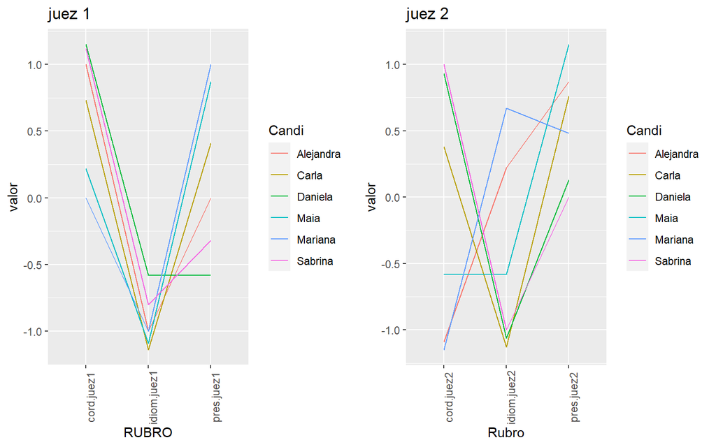

```r
Rubro=as.factor(dj2$rubro)
Candi=as.factor(dj2$cand)
plot2=ggplot(dj2,aes(x=Rubro,y=valor))+geom_line(aes(x=Rubro,y=valor,group =Candi,color=Candi))+ labs(title = "juez 2")+theme(axis.text.x  = element_text(angle=90))
ggarrange(plot1,plot2)
```

# Ejercicio 2

1. Clasificar las variables de la base. Para las variables numéricas construir un gráfico de coordenadas paralelas

**Nacionalidad** Categórica

**Edad**: continua discretizada

**Sexo**: categórica

**Estatura**: cuantitativa continua

**Sitio**: categórica

**Uso**: cuantitativa continua

**Temperatura**: cuantitativa continua

**Autos**: cuantitativa discreta

**Cigarrillos**: cuantitativa discreta

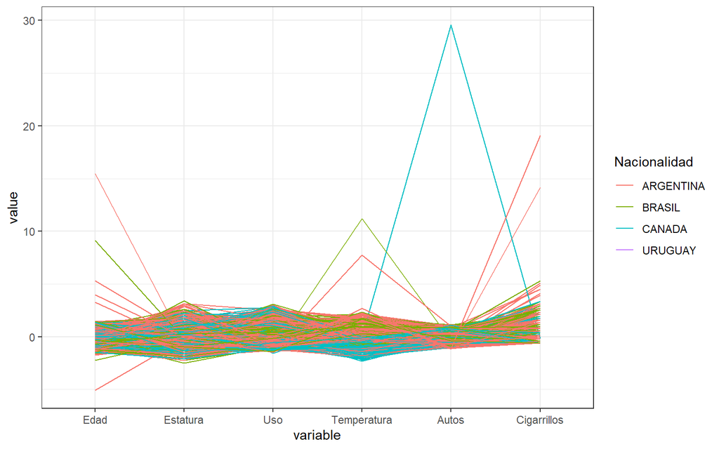

```r
internet <- read_excel("C:/Users/Debora/Dropbox/AustralPosgrado/DataScience/Datos/Internet2017.xls")

grafica <- ggparcoord(internet, columns=c(3,5,7:10), groupColumn="Nacionalidad")
grafica+theme_bw()
```

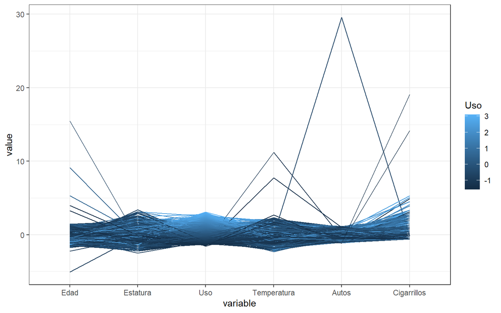

```r
grafica1 <- ggparcoord(internet, columns=c(3,5,7:10), groupColumn="Uso")

grafica1+theme_bw()
```

## Esta gráfica no es adecuada para visualizar tantos individuos y conviene cuando los datos están agrupados.

2. Construir la tabla de frecuencias de la variable sexo. ¿Hay algún valor que llame la atención? ¿Qué tipo de error considera que es?

```r
internet%>%select(Sexo)%>%table()
```

```
## Sexo
##   0   1   2
##   1 684 815
```

aparece un valor 0, aparenta ser un error de tipeo

3. Ordenar los datos por la variable Edad. ¿Encontró algún valor extraño? ¿Qué tipo de error puede ser?

```r
internet%>%select(Edad)%>%arrange(-Edad)
```

```
## # A tibble: 1,500 × 1
##     Edad
##    <dbl>
##  1   280
##  2   180
##  3   120
##  4    99
##  5    88
##  6    60
##  7    60
##  8    60
##  9    60
## 10    60
## # … with 1,490 more rows
```

```r
internet%>%select(Edad)%>%summary()
```

```
##       Edad
##  Min.   :-44.00
##  1st Qu.: 24.00
##  Median : 35.00
##  Mean   : 36.18
##  3rd Qu.: 48.00
##  Max.   :280.00
```

Aparecen valores negativos y una edad de 280 años.

Construir la tabla de frecuencias de la variable Sitio. ¿Encuentra algún valor que le llame la atención? ¿Qué tipo de error puede ser?

```r
internet%>%select(Sitio)%>%table()
```

```
## Sitio
##   1   2   3   4   5   6   7   8  28
## 104 273 172 141 271 140 397   1   1
```

**Los sitios 8 y 28 no existen, debe ser un error de carga o tipeo.**

4. Proceda de forma similar para las variables Temperatura, Autos y Cigarrillos.

```r
internet%>%select(Cigarrillos)%>%arrange(-Cigarrillos)
```

```
## # A tibble: 1,500 × 1
##    Cigarrillos
##          <dbl>
##  1         100
##  2          75
##  3          30
##  4          29
##  5          28
##  6          26
##  7          26
##  8          24
##  9          23
## 10          20
## # … with 1,490 more rows
```

```r
internet%>%select(Cigarrillos)%>%summary()
```

```
##   Cigarrillos
##  Min.   :  0.000
##  1st Qu.:  0.000
##  Median :  2.000
##  Mean   :  3.049
##  3rd Qu.:  4.000
##  Max.   :100.000
```

**Llama la atención el 100**.

```r
internet%>%select(Autos)%>%arrange(-Autos)
```

```
## # A tibble: 1,500 × 1
##    Autos
##    <dbl>
##  1  2680
##  2   200
##  3   200
##  4   200
##  5   200
##  6   200
##  7   200
##  8   200
##  9   199
## 10   199
## # … with 1,490 more rows
```

**EL 2680 aparenta ser un error de tipeo**.

```r
internet%>%select(Temperatura)%>%arrange(-Temperatura)
```

```
## # A tibble: 1,500 × 1
##    Temperatura
##          <dbl>
##  1         131
##  2          94
##  3          40
##  4          36
##  5          36
##  6          35
##  7          35
##  8          35
##  9          35
## 10          35
## # … with 1,490 more rows
```

**El 131 y el 94 parecen ser errores de carga**.

5. Elimine de la base los valores que no son posibles y que seguramente corresponde a un error de tipeo. Detalle valores/registros que le hayan llamado la atención pero no deban ser eliminados necesariamente.

```r
intTem<-internet%>%select(Temperatura)%>%mutate(temperatura=ifelse(Temperatura>40,NA,Temperatura))

intAut<-internet%>%select(Autos)%>%mutate(autos=ifelse(Autos>200|Autos<0,NA,Autos))

intEd<-internet %>%select(Edad)%>%mutate(edad=ifelse(Edad>100|Edad<5,NA,Edad))

intUso<-internet%>%select(Uso)%>%mutate(uso=ifelse(Uso<0,NA,Uso))

intSit<-internet%>%select(Sitio)%>%mutate(sitio=ifelse(Sitio>7,NA,Sitio))
```

6. ¿Para cuáles de las variables tiene sentido calcular la media? ¿Y la mediana?

Media para las cuantitativas solamente y mediana para las ordinales o cuantitativas.

```r
intEd%>%summarise(Media=mean(edad,na.rm=TRUE),Mediana=median(edad,na.rm=TRUE))
```

```
## # A tibble: 1 × 2
##   Media Mediana
##   <dbl>   <dbl>
## 1  35.9      35
```

**son valores similares, no impresiona asimetría**.

```r
intAut%>%summarise(Media=mean(autos,na.rm=TRUE),Mediana=median(autos,na.rm=TRUE))
```

```
## # A tibble: 1 × 2
##   Media Mediana
##   <dbl>   <dbl>
## 1  99.1      99
```

**no hay asimetría aparentemente.**

```r
intUso%>%summarise(Media=mean(uso,na.rm=TRUE),Mediana=median(uso,na.rm=TRUE))
```

```
## # A tibble: 1 × 2
##   Media Mediana
##   <dbl>   <dbl>
## 1  111.      97
```

**Acá se observa asimetría por la derecha, la media es muy superior a la mediana**.

```r
intTem%>%summarise(Media=mean(temperatura,na.rm=TRUE),Mediana=median(temperatura,na.rm=TRUE))
```

```
## # A tibble: 1 × 2
##   Media Mediana
##   <dbl>   <dbl>
## 1  10.8    10.5
```

**no se aprecia asimetría en esta variable** .

7. ¿Cuáles de las variables le parecen simétricas a partir de estos resúmenes? Confirme estas observaciones mediante un boxplot.

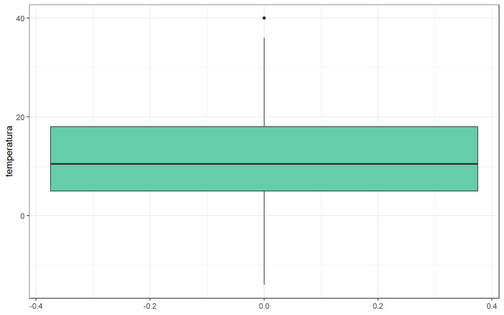

```r
intTem%>%ggplot()+geom_boxplot(aes(y=temperatura),fill="aquamarine3")+theme_bw()
```

**se aprecia la presencia de un outlier alto**.

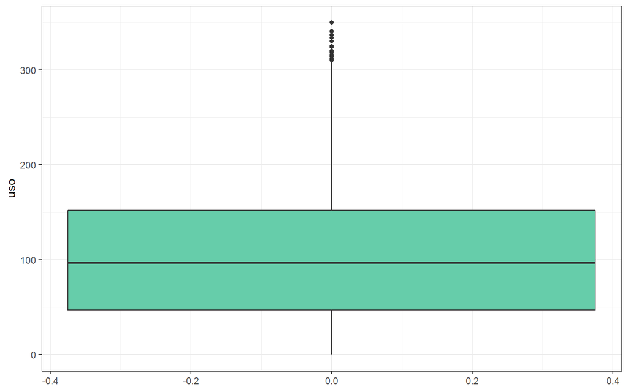

```r
intUso%>%ggplot()+geom_boxplot(aes(y=uso),fill="aquamarine3")+theme_bw()
```

**En este caso hay muchos valores atípicos altos**.

8. Calcular la desviación intercuartil y detectar presencia de valores salvajes moderados y severos.

```r
Q1_uso<-summary(intUso$uso)[2]
Q3_uso<-summary(intUso$uso)[5]
DI_uso=Q3_uso-Q1_uso
VAI_uso<-Q1_uso-1.5*DI_uso
VAS_uso<-Q3_uso+1.5*DI_uso
VLS_uso<-Q3_uso+3*DI_uso
VLI_uso<-Q1_uso-3*DI_uso
rbind(DI_uso,VAS_uso,VAI_uso,VLI_uso,VLS_uso)
```

```
##         3rd Qu.
## DI_uso    105.0
## VAS_uso   309.5
## VAI_uso  -110.5
## VLI_uso  -268.0
## VLS_uso   467.0
```

```r
which(intUso$uso>VAS_uso)
```

```
##  [1]   20   65  137  213  298  315  361  428  495  502  612  743  762  827  873
## [16]  895  948  978 1002 1060 1149 1162 1236 1240 1285 1300 1459
```

```r
which(intUso$uso<VAI_uso)
```

```
## integer(0)
```

```r
which(intUso$uso>VAS_uso&intUso$uso>VLS_uso)
```

```
## integer(0)
```

```r
which(intUso$uso<VAI_uso&intUso$uso>VLI_uso)
```

```
## integer(0)
```

# Ejercicio 3

## Gráficos univariados y multivariados

### (Datos: Gorriones.xls)

Base de datos: Se han registrado para 49 gorriones las siguientes variables zoo-métricas: - a) Largo total - b) Extensión alar - c) Largo del pico y cabeza - d) Largo del húmero - e) Largo de la quilla del esternón - f) Sobrevida (1) Si, (-1) No

- a Indicar en cada caso de que tipo de variable se trata.

```r
# leemos la base de datos
gorriones <- read_excel("C:/Users/Debora/Dropbox/CristinaBrio/gorriones.xlsx")
gorriones
```

```
## # A tibble: 49 × 7
##    pajaro largototal extension cabeza humero esternon sobrevida
##     <dbl>      <dbl>     <dbl>  <dbl>  <dbl>    <dbl>     <dbl>
##  1      1        156       245   31.6   18.5     20.5         1
##  2      2        154       240   30.4   17.9     19.6         1
##  3      3        153       240   31     18.4     20.6         1
##  4      4        153       236   30.9   17.7     20.2         1
##  5      5        155       243   31.5   18.6     20.3         1
##  6      6        163       247   32     19       20.9         1
##  7      7        157       238   30.9   18.4     20.2         1
##  8      8        155       239   32.8   18.6     21.2         1
##  9      9        164       248   32.7   19.1     21.1         1
## 10     10        158       238   31     18.8     22           1
## # … with 39 more rows
```

Largototal, extension, cabeza, humero, esternon son variables continuas (mediciones) por su parte sobrevida es categórica (la vamos a considerar un factor).

- b Confeccionar un informe para cada variable( univariado).

```r
gorriones%>%str() # nos muestra que hay en cada variable
```

```
## tibble [49 × 7] (S3: tbl_df/tbl/data.frame)
##  $ pajaro    : num [1:49] 1 2 3 4 5 6 7 8 9 10 ...
##  $ largototal: num [1:49] 156 154 153 153 155 163 157 155 164 158 ...
##  $ extension : num [1:49] 245 240 240 236 243 247 238 239 248 238 ...
##  $ cabeza    : num [1:49] 31.6 30.4 31 30.9 31.5 32 30.9 32.8 32.7 31 ...
##  $ humero    : num [1:49] 18.5 17.9 18.4 17.7 18.6 19 18.4 18.6 19.1 18.8 ...
##  $ esternon  : num [1:49] 20.5 19.6 20.6 20.2 20.3 20.9 20.2 21.2 21.1 22 ...
##  $ sobrevida : num [1:49] 1 1 1 1 1 1 1 1 1 1 ...
```

```r
gorriones%>%glimpse() # nos muestra como esta almacenada cada variable
```

```
## Rows: 49
## Columns: 7
## $ pajaro     <dbl> 1, 2, 3, 4, 5, 6, 7, 8, 9, 10, 11, 12, 13, 14, 15, 16, 17, …
## $ largototal <dbl> 156, 154, 153, 153, 155, 163, 157, 155, 164, 158, 158, 160,…
## $ extension  <dbl> 245, 240, 240, 236, 243, 247, 238, 239, 248, 238, 240, 244,…
## $ cabeza     <dbl> 31.6, 30.4, 31.0, 30.9, 31.5, 32.0, 30.9, 32.8, 32.7, 31.0,…
## $ humero     <dbl> 18.5, 17.9, 18.4, 17.7, 18.6, 19.0, 18.4, 18.6, 19.1, 18.8,…
## $ esternon   <dbl> 20.5, 19.6, 20.6, 20.2, 20.3, 20.9, 20.2, 21.2, 21.1, 22.0,…
## $ sobrevida  <dbl> 1, 1, 1, 1, 1, 1, 1, 1, 1, 1, 1, 1, 1, 1, 1, 1, 1, 1, 1, 1,…
```

```r
gorriones %>%select(largototal:esternon) %>% summary() # nos hace un resumen para cada variable
```

```
##    largototal    extension         cabeza          humero         esternon
##  Min.   :152   Min.   :230.0   Min.   :30.10   Min.   :17.20   Min.   :18.60
##  1st Qu.:155   1st Qu.:238.0   1st Qu.:30.90   1st Qu.:18.10   1st Qu.:20.20
##  Median :158   Median :242.0   Median :31.50   Median :18.50   Median :20.70
##  Mean   :158   Mean   :241.3   Mean   :31.46   Mean   :18.45   Mean   :20.83
##  3rd Qu.:161   3rd Qu.:245.0   3rd Qu.:32.00   3rd Qu.:18.80   3rd Qu.:21.50
##  Max.   :165   Max.   :252.0   Max.   :33.40   Max.   :19.80   Max.   :23.10
```

```r
sobrev=as.factor(gorriones$sobrevida)
```

- c Realizar en el caso que corresponda un histograma. Ensayar el número de intervalos que conviene en cada variable, indicar si utiliza algún criterio.

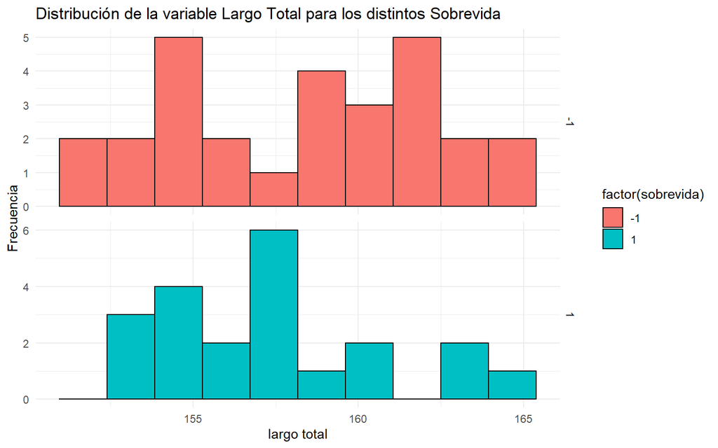

```r
ggplot(gorriones) +
  geom_histogram(bins = 10, aes(x = largototal, fill = factor(sobrevida)), color = 'black') + facet_grid(sobrevida~., scales = 'free') +
  xlab("largo total") +
  ylab("Frecuencia") +
  ggtitle("Distribución de la variable Largo Total para los distintos Sobrevida") +
  theme_minimal()
```

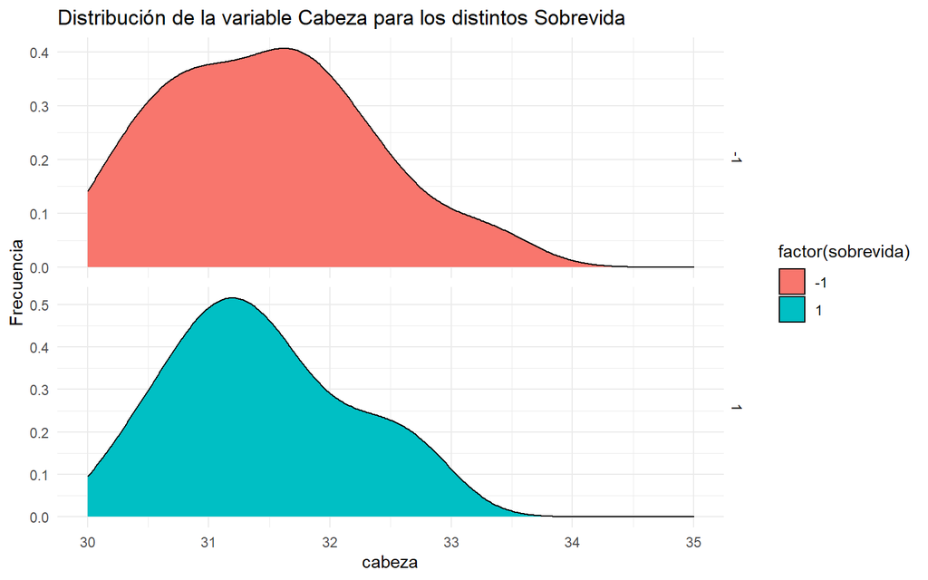

```r
ggplot(gorriones) +
  geom_density( aes(x = cabeza, fill = factor(sobrevida)), color = 'black') + facet_grid(sobrevida~., scales = 'free') +
  xlab("cabeza") + xlim(c(30,35))+
  ylab("Frecuencia") +
  ggtitle("Distribución de la variable Cabeza para los distintos Sobrevida") +
  theme_minimal()
```

4. Realizar un boxplot comparativo para cada una de estas variables particionando por el grupo definido por la supervivencia. ¿Le parece que alguna de estas variables está relacionada con la supervivencia, es decir que toma valores muy distintos en ambos grupos? Analizar en todos los casos la presencia de outliers.

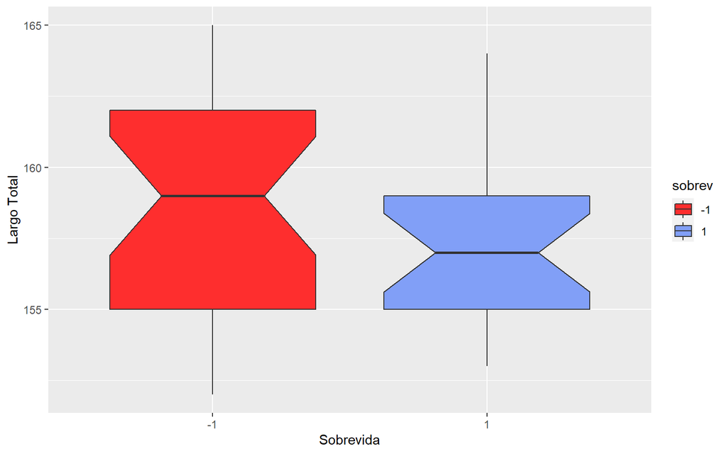

```r
ggplot(gorriones,aes(x=sobrev,y=largototal,fill=sobrev))+geom_boxplot(notch=TRUE)+
  scale_fill_manual(values=c("#FE2E2E","#819FF7")) +# cambiamos los colores
  xlab("Sobrevida")+ylab("Largo Total")
```

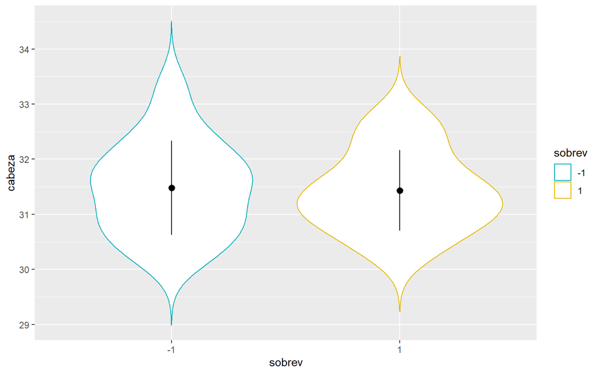

```r
gorriones %>% ggplot(aes(x = sobrev,
             y = cabeza)) +
  geom_violin(trim = FALSE, aes(color = sobrev)) +
  stat_summary(fun.data = "mean_sdl",
               fun.args = list(mult = 1),
               geom = "pointrange",
               color = "black") +
  scale_color_manual(values = c("#00AFBB", "#E7B800"))
```

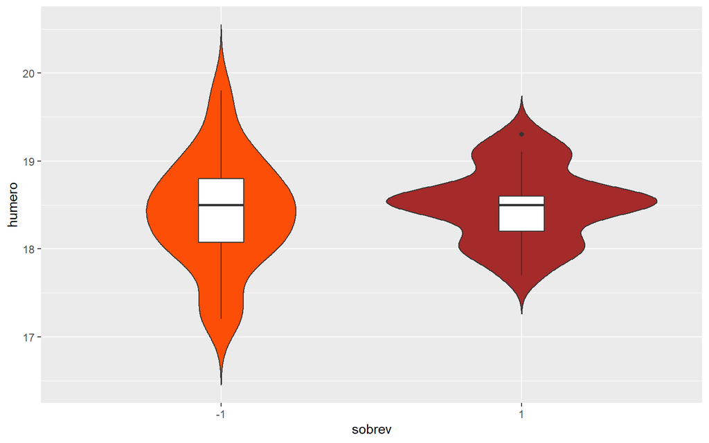

```r
gorriones %>%
   ggplot(aes(x = sobrev,
             y = humero)) +
  geom_violin(aes(fill = sobrev), trim = FALSE) +
  geom_boxplot(width = 0.15)+
  scale_fill_manual(values = c( "#FC4E07","brown")) +
  theme(legend.position = "none")
```

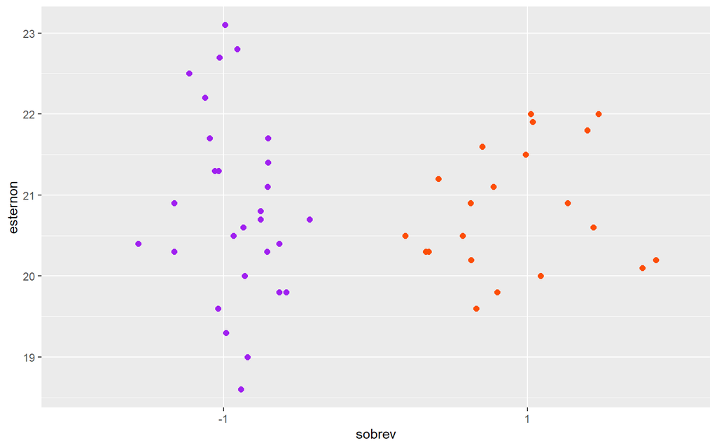

```r
gorriones %>%
    ggplot(aes(x = sobrev,
             y = esternon)) +
  geom_sina(aes(color = sobrev), size = 2)+
  scale_color_manual(values = c( "purple", "#FC4E07")) +
  theme(legend.position = "none")
```

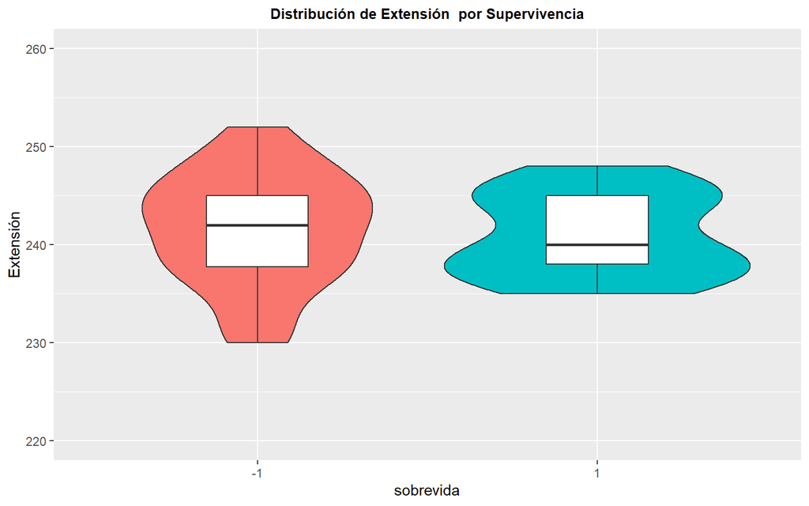

```r
g2 <- gorriones %>%
  ggplot(aes(x=sobrev, y=extension, fill=sobrev)) +
    geom_violin() +
    theme(
      legend.position="none",
      plot.title = element_text(size=10, # tamaño
                                hjust = 0.5, # centrado
                                face="bold", # estilo
                                color = "black")
  ) +ylim(c(220,260))+
  labs( x="sobrevida", y="Extensión",
        title="Distribución de Extensión  por Supervivencia")+geom_boxplot(width = 0.3,fill="white")
g2
```

5. Construir gráficos bivariados para las todas las variables, particionando por el grupo de supervivencia (un color para cada grupo). ¿Observa alguna regularidad que pueda explicar la supervivencia?

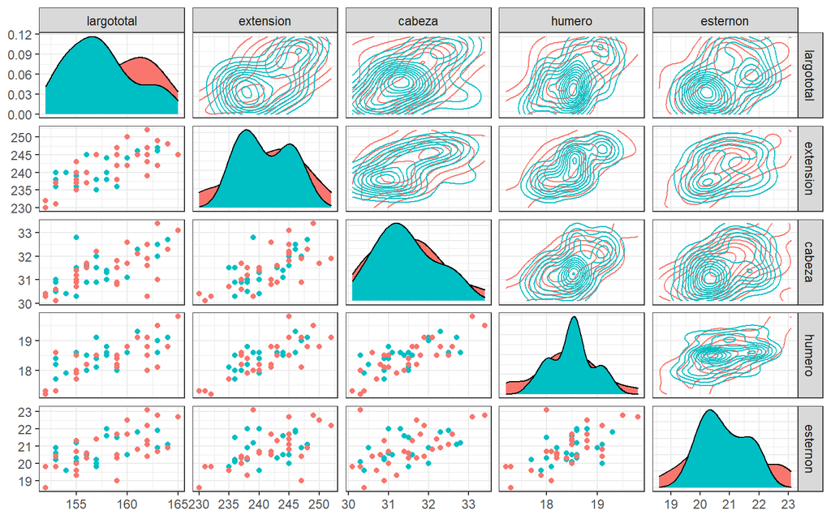

```r
gorr=gorriones%>%select(largototal:esternon)
sobrev=factor(gorriones$sobrevida)
ggpairs(gorr, aes(color=sobrev),
        upper = list(continuous = "density", combo = "box_no_facet"),
        lower = list(continuous = "points" , combo ="dot_no_facet"))+
  theme_bw()
```

6. Construir la matriz de diagramas de dispersión. ¿Considera que algún par de estas medidas están relacionadas? Estudiar si la asociación de algunas de estas medidas es diferente en alguno de los grupos

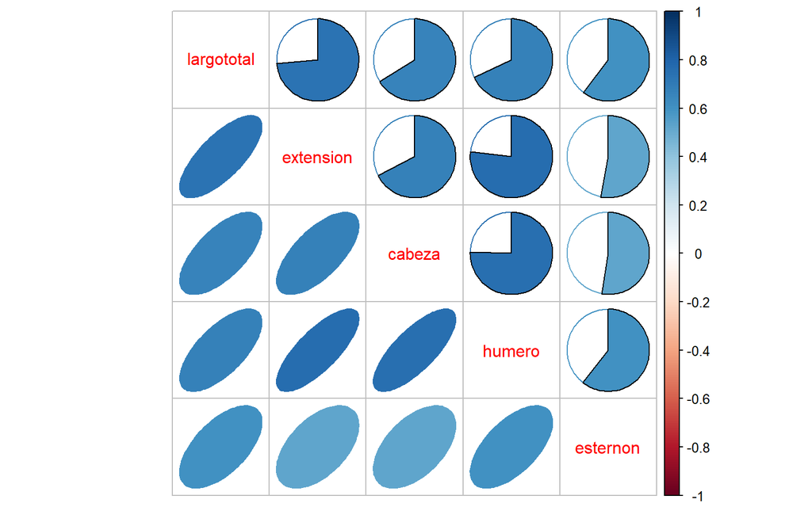

```r
M= cor(gorr)
corrplot.mixed(M, upper = "pie",
         lower = "ellipse")
```

# Ejercicio 5

## Matriz de covarianzas: (Datos Gorriones.xls)

### Para esta base de datos, interesa:

- 1. Dimensión de la base de datos (n= número de observaciones, p= cantidad de variables observadas sobre cada individuo).

```r
View(gorriones)
dim(gorriones) # la dimensión dice 7 columnas pero son 6 variables y 49 registros
```

```
## [1] 49  7
```

```r
#la primer columna corresponde a el orden del registro
```

- 2. Hallar el vector de medias, la matriz de varianzas y covarianzas y la matriz de correlaciones. ¿Qué características tienen estas matrices?

```r
vector_medias=apply(gorr,2,mean)
vector_medias
```

```
## largototal  extension     cabeza     humero   esternon
##  157.97959  241.32653   31.45918   18.44898   20.82653
```

```r
matriz_covarianzas=var(gorr)
round(matriz_covarianzas,3)
```

```
##            largototal extension cabeza humero esternon
## largototal     13.354    13.611  1.922  1.351    2.192
## extension      13.611    25.683  2.714  2.121    2.658
## cabeza          1.922     2.714  0.632  0.327    0.415
## humero          1.351     2.121  0.327  0.296    0.327
## esternon        2.192     2.658  0.415  0.327    0.983
```

```r
matriz_correlacion=cor(gorr)
round(matriz_correlacion,3)
```

```
##            largototal extension cabeza humero esternon
## largototal      1.000     0.735  0.662  0.680    0.605
## extension       0.735     1.000  0.674  0.769    0.529
## cabeza          0.662     0.674  1.000  0.756    0.526
## humero          0.680     0.769  0.756  1.000    0.607
## esternon        0.605     0.529  0.526  0.607    1.000
```

- 3. Explicar que representa el elemento m11 de la matriz de varianzas y covarianzas, ídem para el elemento m31.

**m11=var(largototal)**

**m31=covarianza(largototal, cabeza)**

- 4. Explicar que representa el elemento m22 de la matriz de correlaciones, ídem para el elemento m13.

**m22=cor(extension,extension)=1**

(todos los elementos diagonales son 1)

**m13=m31=cor(largotal,cabeza)**

- 5. Relacionar los elementos m21,m11ym22 de la matriz de varianzas y covarianzas con el elemento m12 de la matriz de correlaciones.

     corr(var1,var2)=cov(var1,var2)/raiz(var(var1))*raiz(var(var2))